# 5.5 Cartography II: Projection, context, and labels

When we include a map in a report, we need to do more than display our spatial data. We also need to give readers enough information to locate the study area, judge its size, and identify the features that we discuss in the text.

In *4.5 Cartography with ggplot2 and tmap*, we focused on what to draw and how to encode a value. In this lesson, we will build on those ideas as we prepare a map of Tara’s nest study for a report. We will begin with her nest records and habitat patches, then add the surrounding information that a reader will need to make sense of them.

Across this lesson, you will learn:

- How the CRS affects the appearance of a map and how to set it with `coord_sf()`
- How to combine plots into one figure with *patchwork*
- How to create a map extent from a buffered bounding box
- Why we might simplify a boundary layer and how to do so with `ms_simplify()`
- How to build a locator map and place it inside another map
- How to place labels near narrow features without covering the data
- How to encode a second variable with symbol size
- How to add a basemap, north arrow, scale bar, and graticule to a *tmap* map
- How to assemble these elements into a map that readers can interpret without the accompanying prose

*This lesson is optional, and it follows *4.5 Cartography with ggplot2 and tmap*, which is also optional. Nothing required later in the course depends on either.*

**Important!** Before starting this tutorial, be sure that you have completed all preliminary and previous lessons!

## Data for this lesson

**`nests.csv`**: Bird nests found and monitored in a nest monitoring study area, provided as a tabular dataset with one row per nest. Locations were recorded with a handheld GPS unit in a geodetic Coordinate Reference System with the datum WGS 84 and EPSG code 4326.

The data include the following variables:

- `nest_id`, character: The **primary key** for each nest.
- `patch_id`, character: The habitat patch the nest was found in, a **foreign key** to `patches.geojson`.
- `species_code`, character: The four-letter alpha code of the species, `UNKN` where the species was not identified.
- `common_name`, character: The common name of the species, `Unknown` where the species was not identified.
- `discovery_date`, date: The date the nest was found.
- `discovery_stage`, character: The stage of the nesting attempt when the nest was found.
- `height_m`, numeric: The height of the nest above the ground, in meters, measured from the ground to the nest rim.
- `nest_fate`, character: The outcome of the nesting attempt.
- `longitude`, numeric: The longitude of the nest, in decimal degrees.
- `latitude`, numeric: The latitude of the nest, in decimal degrees.

**`patches.geojson`**: A polygon shapefile of habitat patches in a nest monitoring study area. The data are in a projected Coordinate Reference System with the datum WGS 84 and EPSG code 32617 (UTM Zone 17N).

The data include the following fields:

- `patch_id`, character: The **primary key** for each habitat patch.
- `patch_label`, character: The name of each habitat patch.

**`counties.geojson`**: A polygon shapefile of all counties in the United States obtained from US Census data using the *tigris* package. The data are in a projected Coordinate Reference System with the datum NAD83 and EPSG code 5070.

Relevant fields include:

- `STATEFP`, character: A **foreign key** to the US state in the `states` data.
- `statefp`, character: A **foreign key** to the US state in the `states` data.
- `COUNTYFP`, character: An ID assigned to a given county in a given state.
- `countyfp`, character: An ID assigned to a given county in a given state.
- `GEOID`, character: The **primary key** for each county (*Note: These values are a concatenation of `STATEFP` and `COUNTYFP`*).
- `geoid`, character: The **primary key** for each county (*Note: These values are a concatenation of `STATEFP` and `COUNTYFP`*).
- `NAME`, character: The name of each county.
- `name`, character: The name of each county.
- `STUSPS`, character: The two-letter postal code of the state each county is within.
- `stusps`, character: The two-letter postal code of the state each county is within.
- `STATE_NAME`, character: The name of the state each county is within.
- `state_name`, character: The name of the state each county is within.
- `ALAND`, numeric: The area covered by land in each census tract, in square meters.
- `aland`, numeric: The area covered by land in each census tract, in square meters.
- `AWATER`, numeric: The area covered by water in each census tract, in square meters.
- `awater`, numeric: The area covered by water in each census tract, in square meters.

**`states`** (`.dbf`, `.prj`, `.shp`, `.shx`): A polygon shapefile of US states (not including Hawaii). The data are in an unprojected Coordinate Reference System with the datum NAD83 and EPSG code 4269.

The data include the following fields:

- `GEOID`, character: The **primary key** for each state.
- `NAME`, character: The name of each state.
- `REGION`, character: The region of the United States where each state is located.
- `AREA`, numeric: The total area of each state, in square kilometers.
- `ttl__10`, numeric: The total population of each state in 2010.
- `ttl__15`, numeric: The total population of each state in 2015.

## Set up your session

Begin with a clean session:

1. Ensure that your **Global Environment** is empty.
2. In the *History* tab of your **workspace pane**, ensure that your **session history** is empty.

Next:

1. Create a script file.
2. Save your script file as `scripts/cartography_ii.R`.
3. Add metadata as a comment on the top of the file.
4. Create a **code section** called “`setup`” after the metadata.
5. Attach *sf*, *patchwork*, *tmap*, and the packages that comprise the **core tidyverse**, then load the module 3 source script.

Your script should look something like:

```r
# My code for the cartography II tutorial

# setup --------------------------------------------------------

library(sf)
library(patchwork)
library(tmap)
library(tidyverse)

# Load the source script:

source("scripts/source_script_module_3.R")
```

*Note: We will stay in `tmap_mode("plot")`, the default, throughout this lesson. Our goal is to prepare a static map that can be printed or embedded in a report. With an interactive map, readers can pan and zoom, so some of the decisions below become less important.*

Next, please create a code section called “`read and pre-process data`”. We will use Tara’s nest records and habitat patches to build the main map, the counties of Virginia to build a locator map, and the states of the contiguous United States to compare projections:

```r
nests <-
  read_csv(
    "data/raw/nests.csv",
    show_col_types = FALSE
  ) %>%
  st_as_sf(
    coords = c("longitude", "latitude"),
    crs = 4326
  ) %>%
  st_transform(crs = 32617)

patches <-
  st_read(
    "data/raw/shapefiles/patches.geojson",
    quiet = TRUE
  )

counties <-
  st_read(
    "data/raw/shapefiles/counties.geojson",
    quiet = TRUE
  )

states <-
  st_read(
    "data/raw/shapefiles/states.shp",
    quiet = TRUE
  )
```

Tara recorded the nest locations as longitude and latitude. We will transform them to UTM zone 17N (EPSG 32617), the projected CRS that contains the study area. Tara digitized the patch boundaries in that CRS, so the two layers will share a CRS when we map them.

## Choosing a projection

We previously chose a CRS to increase the accuracy of distance and area calculations (see *3.4 The coordinate reference system: Why it matters and how to use it*). Our choice also affects how spatial features appear on a map.

With *ggplot2*, we can use `coord_sf()` to draw a map in a different CRS without changing the spatial object. Let’s compare two projections of the contiguous United States, with Virginia highlighted in green:

```r
land <-
  states %>%
  mutate(
    in_virginia = NAME == "Virginia"
  )
```

Both maps will use the same layer and colors. Rather than writing those elements twice, we will define them once and assign the resulting plot to the name `base_map`. We can then add a different `coord_sf()` call to each version:

```r
base_map <-
  ggplot(land) +

  # Add geometries:

  geom_sf(
    aes(fill = in_virginia),
    color = "grey45",
    linewidth = 0.15,
    show.legend = FALSE
  ) +

  # Define the scales:

  scale_fill_manual(
    values = c("TRUE" = "darkgreen", "FALSE" = "grey85")
  ) +

  # Define the theme:

  theme_void()
```

In the code above, we used `scale_fill_manual()` to assign a color to each fill value and `show.legend = FALSE` to suppress the legend. Because the color identifies Virginia rather than encoding a variable, a legend would not add useful information.

We can use *patchwork* to combine the two plots into one figure. To place them side by side, we add them with `+`:

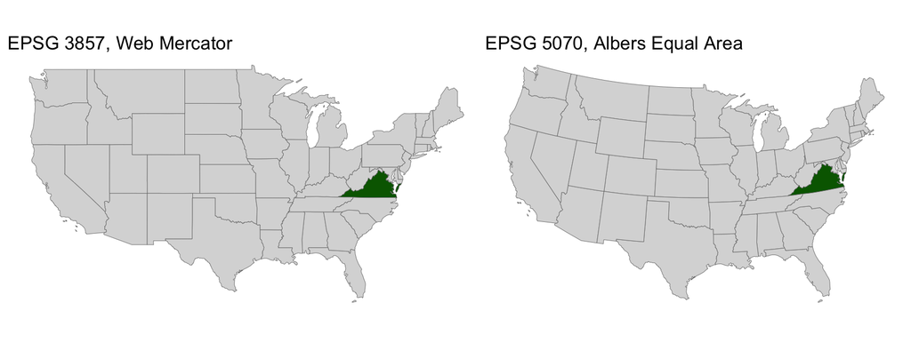

```r
mercator <-
  base_map +

  # Define the CRS and the title:

  coord_sf(crs = 3857) +
  labs(title = "EPSG 3857, Web Mercator")

albers <-
  base_map +

  # Define the CRS and the title:

  coord_sf(crs = 5070) +
  labs(title = "EPSG 5070, Albers Equal Area")

mercator + albers
```

Notice that we used the same data in each panel and changed only the `crs =` argument. The differences between the maps therefore result from the projection rather than the underlying spatial object.

Tile servers typically use Web Mercator (EPSG 3857) for web basemaps. In this CRS, small features retain their local shapes, but area distortion increases toward the poles. As a result, Montana and Maine appear larger relative to Texas and Florida than they are on the ground.

Albers Equal Area (EPSG 5070) retains proportional area throughout the contiguous United States. This makes it a better choice when our goal is to compare the sizes of counties, states, or habitats. The curved northern border and narrower states at the eastern and western edges may look unusual at first, but they are the visible consequences of that tradeoff.

Match the projection to the comparison!

No projection can preserve area, shape, distance, and direction at the same time. The important step is to choose the property that matters for the map you are making:

- Use an equal-area projection to compare the sizes of ranges, protected areas, or habitat classes.
- Use a conformal projection, which preserves local shape, for the outlines of small features.
- Use Web Mercator for a map that includes a web basemap because tile servers use this CRS.
- Use the appropriate UTM zone for a compact study area, where local distortion is small, as this course does for Tara’s patches.

Because readers cannot determine the projection from the map alone, name it in the caption alongside the data source.

**Note**

*Note:* We can make the same choice in a *tmap* map by supplying the selected CRS to the `crs =` argument of `tm_shape()`.

Check your understanding

You are drawing a map of the area of protected land in Montana and Florida. Which projection should you use?

An equal-area projection Web Mercator, so it matches the basemap EPSG 4326, because it is unprojected Whichever projection the source file arrived in

True or false: Using `coord_sf(crs = 3857)` changes the CRS of the spatial object.

## Mapping the study area

Let’s turn to Tara’s study area. Our starting point is fairly simple: the habitat patches she searched and the nests that she found within them.

If we set the map extent directly from these layers, the outermost features will touch the edge of the frame. That leaves us with no room for labels and very little visual space around the study area. We can create that space by dissolving the patches, buffering the result by 200 meters, and then extracting its bounding box:

```r
map_extent <-
  patches %>%
  st_union() %>%
  st_buffer(dist = 200) %>%
  st_bbox()
```

```
     xmin      ymin      xmax      ymax
 744992.1 4308099.2  747417.0 4309576.4
```

In the code above, we used `st_union()` to dissolve the patches into one geometry, `st_buffer()` to extend that geometry by 200 meters, and `st_bbox()` to obtain the coordinates of the surrounding rectangle (see *5.1 Focus on points: Occurrence records and sampling*).

```r
study_area <-
  ggplot() +

  # Add geometries:

  geom_sf(
    data = patches,
    fill = "darkgreen",
    alpha = 0.25,
    color = "darkgreen"
  ) +
  geom_sf(
    data = nests,
    shape = 21,
    fill = "gold",
    color = "black",
    stroke = 0.2,
    size = 1.5
  ) +

  # Define the CRS:

  coord_sf(
    xlim = map_extent[c("xmin", "xmax")],
    ylim = map_extent[c("ymin", "ymax")]
  ) +

  # Define the theme:

  theme_void() +
  theme(
    panel.border =
      element_rect(
        color = "grey30",
        fill = NA,
        linewidth = 0.4
      )
  )
```

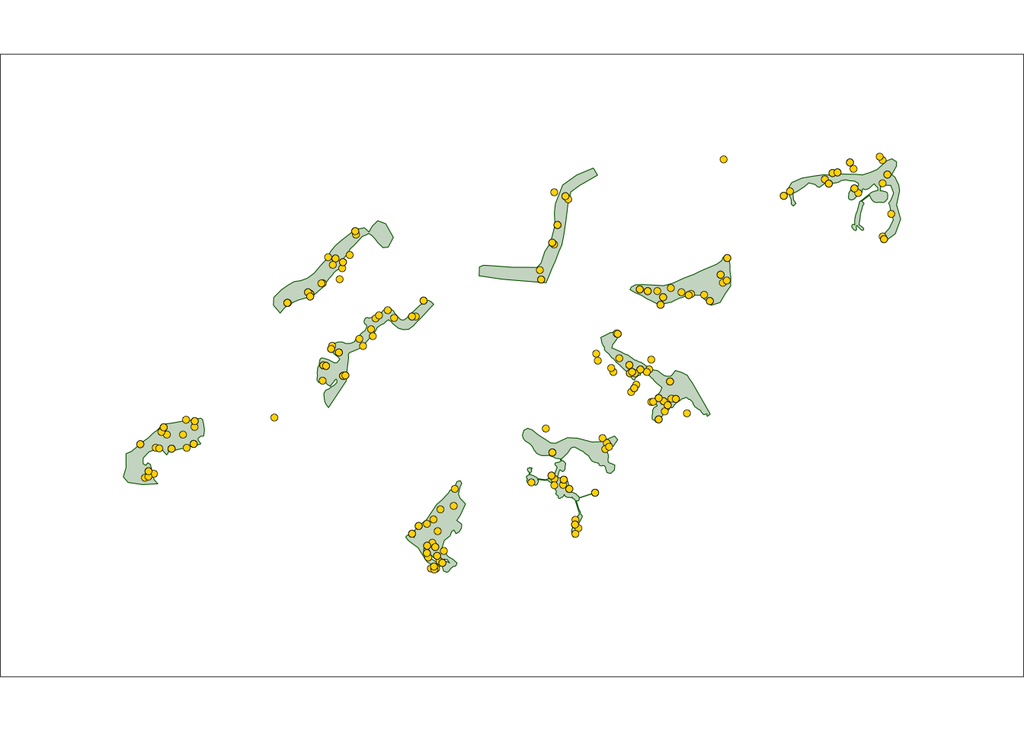

We used `theme_void()` to remove the axes and background. The `theme()` call then changes one part of that theme. Here, `panel.border =` selects the border around the plotting panel, and `element_rect()` describes the rectangle used for it. We set `fill = NA` so that the rectangle does not cover the map. With `shape = 21`, we can set the fill and outline of the nest points separately, and `stroke =` sets the width of the outline. The gold fill and thin black outline will keep each point visible when we add a basemap later.

Inside `coord_sf()`, `xlim =` and `ylim =` set the horizontal and vertical extent of the map. We select those limits from the named coordinates returned by `st_bbox()`.

This is a reasonable start, but it does not yet provide much information to someone who has not worked at the site. A reader cannot identify the patches, locate the study area, or judge distances. We will address each of those limitations and then assemble the pieces into the final map.

## Simplifying boundaries

Spatial layers are often digitized at a much finer resolution than we need for a particular map. That additional detail may be important for other applications, but readers cannot resolve it when the layer appears in a small locator map.

Consider the Virginia county layer. We will use it in our locator map, where several vertices may occupy the same pixel. Let’s first count the vertices in the original layer:

```r
virginia <-
  counties %>%
  filter(STATEFP == "51")

count_vertices(virginia)
```

```
[1] 7818
```

We can use `rmapshaper::ms_simplify()` to reduce that detail while maintaining the shared boundaries between neighboring counties (see *5.3 Focus on polygons: Boundaries, attributes, and areas*). Here, we will retain two percent of the original vertices:

```r
virginia_map <-
  virginia %>%
  rmapshaper::ms_simplify(
    keep = 0.02,
    keep_shapes = TRUE
  )

count_vertices(virginia_map)
```

```
[1] 1073
```

We set `keep_shapes = TRUE` so that every feature remains in the output, including the smallest counties.

At the extent of Virginia, the full outline of the study area would be too small to see. We can represent it with a point instead. To find that position, we will dissolve the patches and calculate the centroid of the resulting geometry:

```r
study_point <-
  patches %>%
  st_union() %>%
  st_centroid() %>%
  st_transform(
    crs = st_crs(virginia)
  )
```

Now let’s draw both versions at the approximate size of the final locator and mark the study area with a red point:

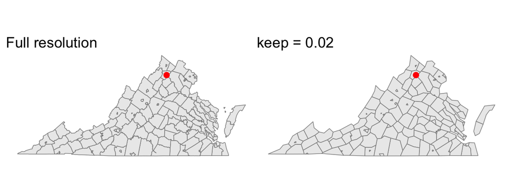

```r
full <-
  ggplot(virginia) +

  # Add geometries:

  geom_sf(
    fill = "grey92",
    color = "grey55",
    linewidth = 0.25
  ) +
  geom_sf(
    data = study_point,
    color = "red",
    size = 2
  ) +

  # Add the title and the theme:

  labs(title = "Full resolution") +
  theme_void()

simplified <-
  ggplot(virginia_map) +

  # Add geometries:

  geom_sf(
    fill = "grey92",
    color = "grey55",
    linewidth = 0.25
  ) +
  geom_sf(
    data = study_point,
    color = "red",
    size = 2
  ) +

  # Add the title and the theme:

  labs(title = "keep = 0.02") +
  theme_void()

full + simplified
```

We use the red point to mark the centroid of the dissolved patches and represent the study area at the extent of Virginia (see *5.1 Focus on points: Occurrence records and sampling*).

Notice what we gained by removing detail that a reader could not resolve. We can still recognize Virginia and its counties, while the study-area marker is now more visually prominent. We also reduced the storage requirements and drawing time.

How much simplification is appropriate depends on the final size of the map. I recommend drawing the simplified layer at that size before deciding whether you have removed too much or not enough.

Simplify the copy you draw, never the one you measure!

This is the same rule that we first applied in *5.3 Focus on polygons: Boundaries, attributes, and areas*. Simplification is a *drawing* decision because it changes areas, lengths, and relationships between adjacent features.

For that reason, I recommend simplifying a copy only after completing your analysis. By assigning the simplified copy to `virginia_map`, we record that it is intended for drawing while retaining `virginia` for analysis.

## Adding a locator map

A **locator map** is a small second map that readers can use to place the study area within a wider, more familiar region. From our patch map alone, an unfamiliar reader cannot determine where the study took place. We know that the patches are in Warren County, Virginia, so let’s add that context.

We will build the locator as an ordinary *ggplot2* map. We will draw the counties of Virginia, highlight Warren County, and mark the study area with the point that we calculated above:

```r
locator <-
  ggplot() +

  # Add geometries:

  geom_sf(
    data = virginia_map,
    fill = "grey92",
    color = "grey55",
    linewidth = 0.25
  ) +
  geom_sf(
    data =
      virginia_map %>%
      filter(NAME == "Warren"),
    fill = "grey55",
    color = "grey30",
    linewidth = 0.3
  ) +
  geom_sf(
    data = study_point,
    color = "red",
    size = 1.8
  ) +

  # Define the theme:

  theme_void()
```

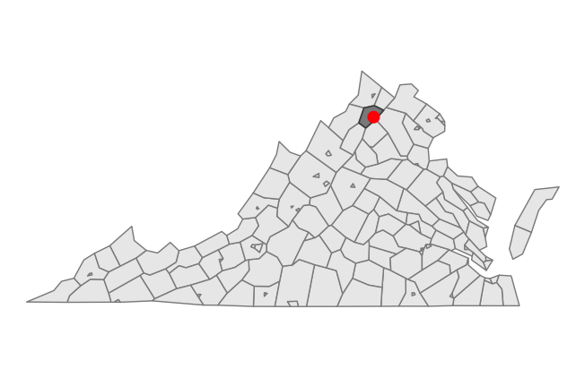

We used `theme_void()` to remove the axes, graticule, and background. The reader can therefore focus on the state, county, and study-area marker.

We can place one plot inside another with the *patchwork* function `inset_element()`. We supply the edges of the inset as proportions of the enclosing panel through the `left =`, `bottom =`, `right =`, and `top =` arguments. Let’s place the locator in the lower-right corner of the study-area map:

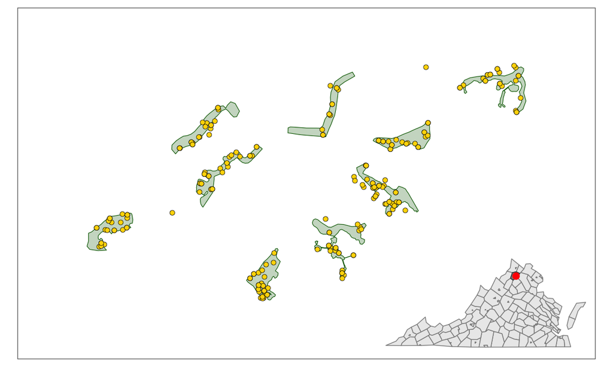

```r
study_area +
  inset_element(
    locator,
    left = 0.62,
    bottom = 0,
    right = 1,
    top = 0.32
  )
```

Building a useful locator map

- Keep the locator visually subordinate to the main map. Pale fills and `theme_void()` work well here.
- Mark the study area with a symbol rather than its true outline. At the extent of a state, a study area of a few hectares will be smaller than a visible point.
- Examine the main map before choosing a corner. The locator should not cover information that the reader needs.

*Note:* We will use `tm_inset()` to add this locator to a *tmap* map at the end of the lesson.

Now you!

Please build a second locator at the extent of the contiguous United States rather than Virginia. In your map, fill Virginia and mark the study area.

*Hint: Use the `states` object for the wider extent. Transform `study_point` to the CRS of `states` before drawing it.*

Click here to see my answer

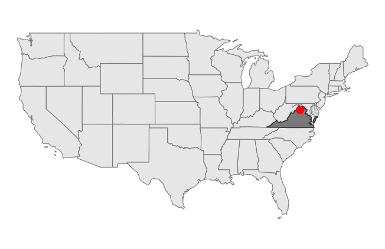

```r
ggplot() +

  # Add geometries:

  geom_sf(
    data = states,
    fill = "grey92",
    color = "grey55",
    linewidth = 0.2
  ) +
  geom_sf(
    data =
      states %>%
      filter(NAME == "Virginia"),
    fill = "grey55",
    color = "grey30",
    linewidth = 0.3
  ) +
  geom_sf(
    data =
      study_point %>%
      st_transform(
        crs = st_crs(states)
      ),
    color = "red",
    size = 1.8
  ) +

  # Define the theme:

  theme_void()
```

At the national extent, readers can use the filled Virginia polygon to interpret the study-area point. The state-level locator includes more detail, however, and will be more useful to most readers of this report. A reader outside of the United States may benefit from seeing both.

## Labeling the features

When a map contains only a few features, direct labels can be easier to read than a legend. To add those labels with *ggplot2*, we need to supply a point position for each one. We can use `st_point_on_surface()` to calculate a point inside each geometry. Recall that a centroid, by contrast, may fall outside of a long or curved polygon (see *5.1 Focus on points: Occurrence records and sampling*):

```r
patches %>%
  st_point_on_surface()
```

```
Simple feature collection with 9 features and 2 fields
Geometry type: POINT
Dimension:     XY
Bounding box:  xmin: 745239.1 ymin: 4308419 xmax: 747161.5 ymax: 4309271
Projected CRS: WGS 84 / UTM zone 17N
           patch_id       patch_label                 geometry
1            coyote            Coyote POINT (745239.1 4308615)
2         firehouse         Firehouse POINT (746017.6 4308419)
3          forest_a          Forest A POINT (746329.3 4308532)
4        forest_geo        Forest Geo POINT (746614.5 4308808)
5       grassland_a       Grassland A POINT (746327.4 4309191)
6       grassland_b       Grassland B POINT (745760.1 4308869)
7 grassland_b_fence Grassland B Fence POINT (745731.3 4309096)
8             leech             Leech POINT (747161.5 4309271)
9       witch_hazel       Witch Hazel POINT (746705.9 4309059)
```

Let’s use `geom_sf_text()` to draw the patch names at those positions:

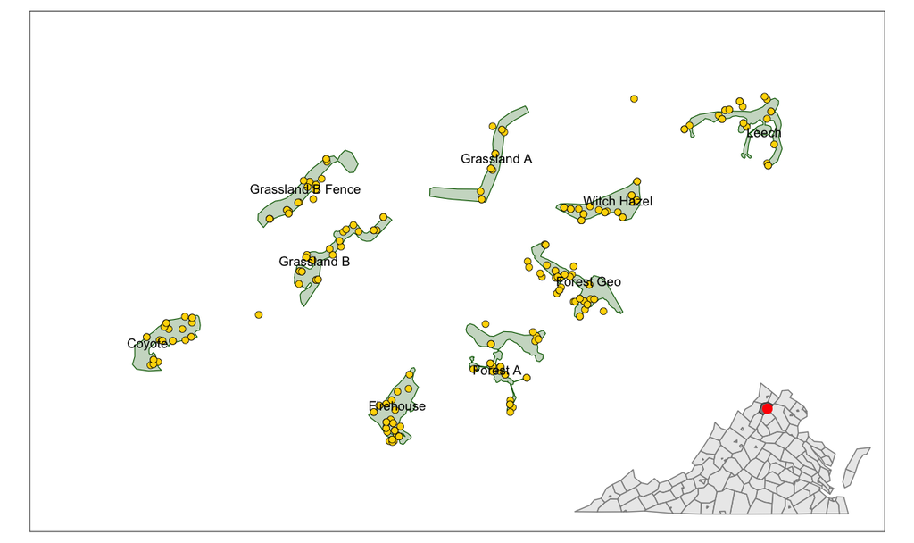

```r
study_area +

  # Add the labels:

  geom_sf_text(
    data =
      patches %>%
      st_point_on_surface(),
    aes(label = patch_label),
    size = 2.3
  ) +

  # Add the locator:

  inset_element(
    locator,
    left = 0.62,
    bottom = 0,
    right = 1,
    top = 0.32
  )
```

Well, that did not work especially well! Each label covers part of its patch, and some labels also cover nests. The narrow patches and text use similar tones, which makes the two difficult to separate.

We can improve the map by placing each label above its patch. To do so, we will use the bounding box of each patch to calculate its northern edge, then use `map_dbl()` to repeat that calculation for every patch in the layer (see *4.4 Iteration*):

```r
patch_labels <-
  patches %>%
  mutate(
    label_x =
      map_dbl(
        geometry,
        \(.geometry) {
          st_bbox(.geometry)[c("xmin", "xmax")] %>%
            mean()
        }
      ),
    label_y =
      map_dbl(
        geometry,
        \(.geometry) {
          st_bbox(.geometry)[["ymax"]]
        }
      ) + 50
  ) %>%
  st_drop_geometry()

patch_labels %>%
  select(
    patch_label,
    label_x,
    label_y
  )
```

```
        patch_label  label_x label_y
1            Coyote 745297.8 4308750
2         Firehouse 746005.8 4308588
3          Forest A 746355.8 4308724
4        Forest Geo 746578.4 4308977
5       Grassland A 746273.2 4309402
6       Grassland B 745848.6 4309058
7 Grassland B Fence 745739.3 4309265
8             Leech 747068.9 4309426
9       Witch Hazel 746643.3 4309174
```

For each geometry, `st_bbox()` returns the named coordinates `xmin`, `xmax`, `ymin`, and `ymax`. The first `map_dbl()` call selects `xmin` and `xmax` and calculates their mean, which is the east-to-west midpoint. The second extracts `ymax`, the northern edge. We add 50 meters to place the text above the patch.

The resulting `label_x` and `label_y` fields are ordinary numeric columns rather than an *sf* geometry, so we will use `geom_text()` to draw the labels. Inside `aes()`, `x =` and `y =` supply their positions and `label =` supplies the text:

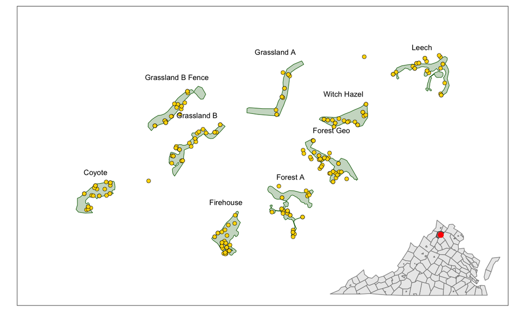

```r
study_area +

  # Add the labels:

  geom_text(
    data = patch_labels,
    aes(
      x = label_x,
      y = label_y,
      label = patch_label
    ),
    size = 2.3
  ) +

  # Add the locator:

  inset_element(
    locator,
    left = 0.62,
    bottom = 0,
    right = 1,
    top = 0.32
  )
```

This is where the buffered extent that we created earlier becomes useful: it gives the northernmost labels enough room to fit inside the frame.

Label the features the reader needs!

Labels are useful only when the reader can read them. When many features occur close together, labeling all of them can make a map worse rather than better. In those cases:

- Label the features the text describes and leave the rest to the legend.
- When features vary in size, you might use `slice_max()` to select and label only the largest few.
- When labels still overlap, we can use `geom_text_repel()` from the *ggrepel* package to separate them and add leader lines. Keep in mind that the resulting labels will no longer sit directly on their features.

*Note:* In a *tmap* map, we can add labels with `tm_text()` by supplying the field name in quotes.

## Two variables on one map

In a choropleth, we use fill to encode a variable for each area. Sometimes, however, the question that we want to answer requires us to compare the spatial patterns of two variables.

Readers tend to interpret fill as a value that applies to the entire area, such as a rate, mean, or density. Counts are often easier to understand when we encode them with symbol size. Let’s calculate two values for each patch: the number of nests and their mean height above the ground.

```r
patch_summary <-
  nests %>%
  st_drop_geometry() %>%
  summarize(
    nests = n(),
    mean_height = mean(height_m, na.rm = TRUE),
    .by = patch_id
  )

patch_map <-
  patches %>%
  left_join(
    patch_summary,
    by = join_by(patch_id)
  )

patch_points <-
  patch_map %>%
  st_point_on_surface()
```

We can now use fill to represent mean nest height and circle area to represent the number of nests in each patch:

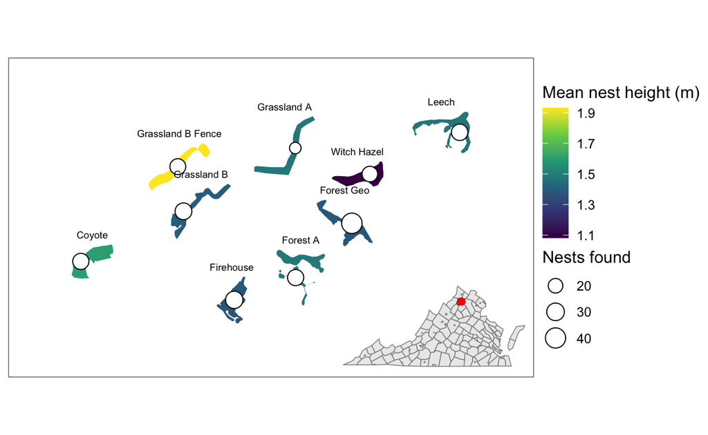

```r
ggplot() +

  # Add geometries:

  geom_sf(
    data = patch_map,
    aes(fill = mean_height),
    color = NA
  ) +
  geom_sf(
    data = patch_points,
    aes(size = nests),
    shape = 21,
    fill = "white",
    color = "black"
  ) +

  # Add the labels:

  geom_text(
    data = patch_labels,
    aes(
      x = label_x,
      y = label_y,
      label = patch_label
    ),
    size = 2.3
  ) +

  # Define the scales:

  scale_fill_viridis_c(name = "Mean nest height (m)") +
  scale_size_area(name = "Nests found", max_size = 6) +

  # Define the CRS:

  coord_sf(
    xlim = map_extent[c("xmin", "xmax")],
    ylim = map_extent[c("ymin", "ymax")]
  ) +
  # Define the theme:

  theme_void() +
  theme(
    panel.border =
      element_rect(
        color = "grey30",
        fill = NA,
        linewidth = 0.4
      )
  ) +

  # Add the locator:

  inset_element(
    locator,
    left = 0.62,
    bottom = 0,
    right = 1,
    top = 0.32
  )
```

Because circle area now represents the number of nests, we do not need to draw the individual nest locations on this map. We use `shape = 21` so that we can set the fill and outline colors separately. The white fill remains visible over the darker patches.

Why use `scale_size_area()` here? With this scale, a value of zero has a symbol size of zero. Under the default size scale, the smallest value in the data still receives a visible symbol. Its circle areas are therefore not proportional to the underlying values. By anchoring the scale at zero, we ensure that twice as many nests produce twice the circle area.

Before placing two variables in one panel, ask whether the comparison actually requires them to share the same space. If it does not, draw two maps. We can use facets to compare the same variable among groups (see *4.5 Cartography with ggplot2 and tmap*), or *patchwork* and `+` to place maps of different variables side by side.

**Note**

Tara designed her patches to be about the same size, roughly 1.5 hectares each. A map of nest counts and a map of nests per hectare would therefore have the same spatial pattern here. When areas differ, however, I recommend using density for the fill because larger areas occupy more of the map regardless of their values.

Check your understanding

Why should we use `scale_size_area()` rather than the default size scale when symbol size encodes a count?

With this scale, a value of zero has zero symbol size, so circle areas are proportional to the values Values correspond to symbol area with this scale but to radius under the default scale Symbols cannot overlap when we use this scale We must use this scale whenever size encodes a numeric field

True or false: A map showing two variables is easier to read than two maps showing one each.

## Adding a basemap

Readers can use the locator map to place the study area within a larger region, but not to navigate the area immediately around the patches. For that, we can add basemap tiles beneath our layers with `tm_basemap()`.

We should use the basemap for geographic context rather than make it the main content of the map. I recommend choosing the least detailed option that still includes the information readers need. Here, we will use `Esri.WorldTopoMap` because readers can use its terrain, roads, and buildings to locate the patches:

```r
basemap_map <-

  # Add the basemap:

  tm_basemap("Esri.WorldTopoMap") +

  # Add the patches:

  tm_shape(patches, bbox = map_extent) +
  tm_polygons(
    fill = "darkgreen",
    fill_alpha = 0.5,
    col = "darkgreen"
  ) +

  # Add the nests:

  tm_shape(nests) +
  tm_dots(
    fill = "gold",
    col = "black",
    lwd = 0.75,
    size = 0.3
  ) +

  # Define the layout:

  tm_layout(frame = TRUE)
```

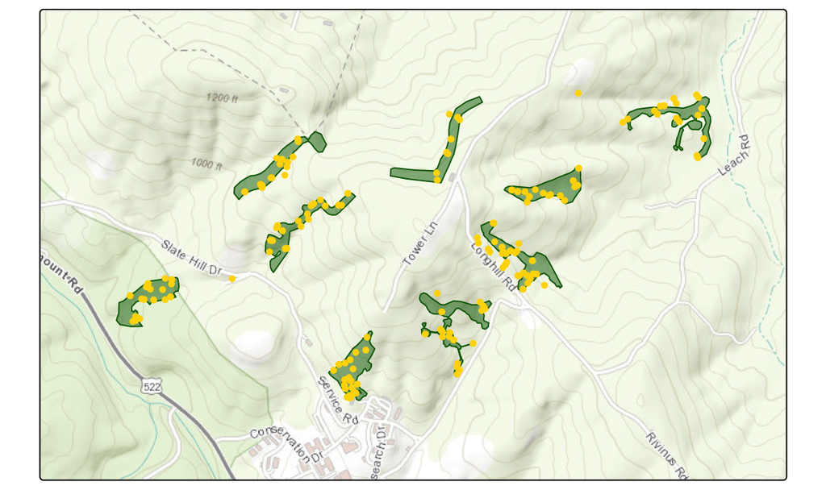

The contours allow readers to place the patches on the hillside, while the roads and buildings help them locate the site. We supplied our buffered bounding box to `bbox =` to set the extent, much as we did with `coord_sf()` for the *ggplot2* maps, and used `tm_layout(frame = TRUE)` to add a frame.

When we use a basemap, we need to consider two things. First, someone produced and published those tiles, so we need to credit the provider. Second, web tile servers use Web Mercator. When we add these tiles, the rendered map will use Web Mercator regardless of the original CRS of our layers (see *Choosing a projection*, above).

Across this small study area, the resulting distortion is negligible. Across a continent, it is not. A web basemap would therefore be a poor choice for a continental comparison of area.

**Note**

Some providers require an API key. Without one, the returned tiles may be stamped *API KEY REQUIRED*. `Esri.WorldGrayCanvas`, `Esri.WorldTopoMap`, `OpenStreetMap`, and `OpenTopoMap` do not require a key. You will need an internet connection to render a map with any of them.

## Adding a north arrow and a scale bar

We can add a north arrow with `tm_compass()` and a scale bar with `tm_scalebar()` (see *4.5 Cartography with ggplot2 and tmap*). As in *ggplot2*, we use `+` to add these elements to a *tmap* map:

```r
oriented_map <-
  basemap_map +

  # Add the orientation and the scale:

  tm_compass(
    type = "arrow",
    position = c("left", "top")
  ) +
  tm_scalebar(position = c("left", "bottom"))
```

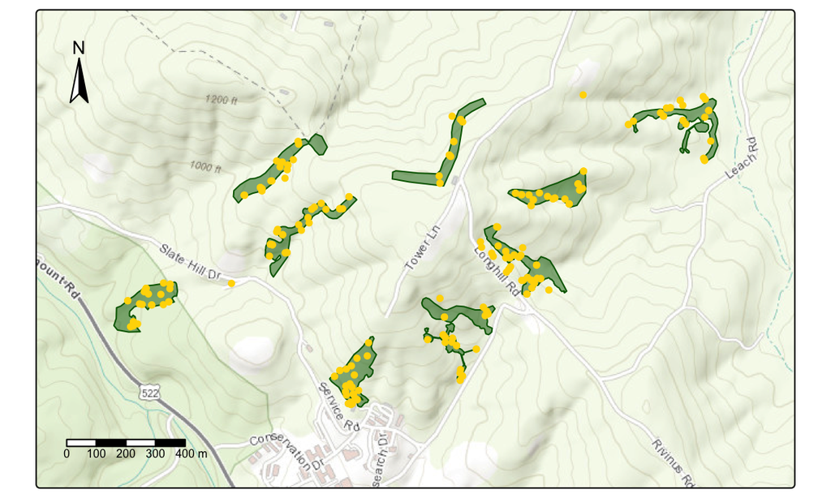

**Note**

Interactive maps usually include a scale bar, and readers can use basemap place names to determine orientation as they pan and zoom. On a static report map, we need to decide whether to provide that information ourselves.

## Adding a graticule

A **graticule** is a grid of meridians and parallels that we can add with `tm_graticules()`. Readers can use the coordinate labels to identify the lines, locate the study area, and determine the map’s orientation.

That information comes with a visual cost: coordinate labels surround the frame and lines cross the map. I typically omit a graticule from a locator map, an inset, or a figure in a slide deck. For a study-area map in a report, however, the coordinates may help a reader find the area again.

Let’s add a graticule to our map:

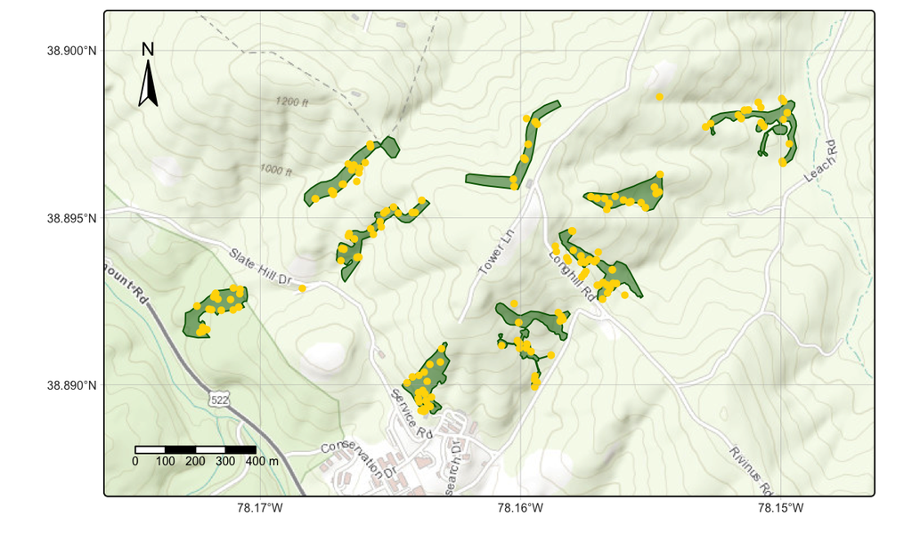

```r
oriented_map +

  # Add the graticule:

  tm_graticules(
    col = "grey70",
    lwd = 0.3,
    labels.size = 0.5,
    n.x = 4,
    n.y = 4
  )
```

We use `n.x =` and `n.y =` to set the approximate number of lines in each direction. With the default values, we would have more labels than this frame can comfortably hold.

I include both a graticule and a north arrow in the finished map below so that you can compare them. In a report, I would usually omit the north arrow because readers can already determine the orientation from the graticule.

## Assembling a publication-quality map

At this point, we have a basemap, orientation, scale, and graticule. We still need to encode a value for the patches and add the patch names that we placed in the *ggplot2* version.

Our label positions are stored as numeric columns rather than an *sf* geometry. To draw the text with *tmap*, we will convert those coordinates to points:

```r
label_points <-
  patch_labels %>%
  st_as_sf(
    coords = c("label_x", "label_y"),
    crs = st_crs(patches)
  )
```

We can then use `tm_text()` to draw the names at those points. By supplying a color to `bgcol =`, we add a panel behind each label and improve the contrast between the text and the basemap.

The finished map also places several components around the map frame. In *tmap* version 4, `tm_pos_in()` places a component inside the map frame, while `tm_pos_out()` places it in the surrounding space. The first value gives the horizontal position and the second gives the vertical position. For example, `tm_pos_in("right", "bottom")` places the locator inside the lower-right corner, while `tm_pos_out("right", "center")` places the legend outside the map along its right side.

`tm_inset()` accepts the `locator` plot that we built above. Its `height =` and `width =` arguments use text-line heights rather than map units. We set `frame = FALSE` to remove the component frame and `box_frame = FALSE` to avoid drawing a box on the main map:

[figure not shown]

```r
# Add the basemap:

tm_basemap("Esri.WorldTopoMap") +

  # Add the patches:

  tm_shape(patch_map, bbox = map_extent) +

  # Add the graticule:

  tm_graticules(
    col = "grey70",
    lwd = 0.3,
    labels.size = 0.5,
    n.x = 4,
    n.y = 4
  ) +
  tm_polygons(
    fill = "mean_height",
    fill.scale =
      tm_scale_intervals(
        style = "quantile",
        n = 3,
        values = "brewer.blues"
      ),
    fill.legend =
      tm_legend(
        title = "Mean nest\nheight (m)",
        position = tm_pos_out("right", "center")
      ),
    fill_alpha = 0.85,
    col = "white",
    lwd = 0.5
  ) +

  # Add the nests:

  tm_shape(nests) +
  tm_dots(
    fill = "gold",
    col = "black",
    lwd = 0.4,
    size = 0.3
  ) +

  # Add the labels:

  tm_shape(label_points) +
  tm_text(
    text = "patch_label",
    size = 0.6,
    bgcol = "white",
    bgcol_alpha = 0.7
  ) +

  # Add the orientation and the scale:

  tm_compass(
    type = "arrow",
    position = c("left", "top"),
    size = 2
  ) +
  tm_scalebar(position = c("left", "bottom")) +

  # Add the locator:

  tm_inset(
    locator,
    position = tm_pos_in("right", "bottom"),
    height = 5,
    width = 6.9,
    frame = FALSE,
    box_frame = FALSE
  ) +
  # Add the title and the credits:

  tm_title("Nests and habitat patches in the 2026 season") +
  tm_credits(
    str_c(
      "Patches and nests: Tara's nest study. Counties: US Census Bureau.",
      "Basemap: Esri. Web Mercator (EPSG:3857).",
      sep = "\n"
    ),
    position = tm_pos_out("center", "bottom"),
    size = 0.45
  ) +

  # Define the layout:

  tm_layout(frame = TRUE)
```

There is a fair bit happening in this map, but readers need each element to answer a question that they cannot answer from the data layers alone:

- From the **title**, readers can identify the subject of the map rather than simply seeing the variable repeated.
- From the **legend title**, readers can identify the variable and its units and interpret the fill (see *5.4 Categorizing spatial data*).
- From the **graticule**, readers can determine the coordinates and orientation of the study area.
- From the **scale bar**, readers can estimate distances. Because the study area is small, distortion across the frame is negligible.
- From the **basemap**, readers can identify the surrounding terrain, roads, and buildings. They can use the **locator** to place the study area within Virginia.
- From the **labels**, readers can identify the patches without losing sight of the mapped features.
- From the **credits**, readers can identify the data, basemap, and projection and verify the map.

Include everything the reader requires inside the frame!

A reader may copy a map from a report into a slide deck, and someone else may copy it from there into a summary for a funder. We will not always be present to explain it! As a result, the information required to interpret the map should remain inside its frame.

Before I render a map for a report, I try to read it from the perspective of someone who has never seen the study area. Can they identify the subject, variable, orientation, scale, location, and data sources? If not, I revise the map.

## Putting it all together

The goal is not to add every possible cartographic element. Instead, add an element when it helps the reader answer a question that they cannot answer from the data layers alone. My own mental model looks like this (click to expand):

[figure not shown]

**Note**

This is *my* mental model for these functions. Your model may differ. What matters is whether you can use it to retrieve the functions needed to solve a problem.

## Take-home points

- The CRS affects the shapes of features on a map. Use `coord_sf(crs = )` for a *ggplot2* map or `tm_shape(crs = )` for a *tmap* map. Neither call changes the spatial object.
- Use an equal-area projection to compare sizes and a conformal projection to compare outlines. The CRS for web basemap tiles is Web Mercator, which does not preserve area. Name the projection in the caption.
- Use `st_buffer()` and `st_bbox()` to create a map extent with space around the outermost features. Use a locator map to place the study area within a region that readers recognize. Remove its axes and graticule with `theme_void()`, mark the study area with a symbol, and add the locator with `inset_element()` or `tm_inset()`.
- Detail that readers cannot resolve increases file size and drawing time and directs attention away from the subject of the map. Use `ms_simplify()` to reduce polygon vertices while maintaining shared boundaries. Simplify a copy for drawing and retain the original for measurement.
- Labels placed on narrow features may be difficult to read. Calculate positions from each feature’s bounding box and use `geom_text()` or `tm_text()` to draw the labels beside the features.
- Readers interpret fill as a value that applies to a whole area. Use symbol size for counts and `scale_size_area()` to anchor a value of zero at zero size.
- Two maps side by side are often easier to read than two variables in one panel. Use one panel only when readers need to compare the variables in the same space.
- Use `tm_basemap()` to add tiles beneath a map. Choose an unobtrusive basemap, credit its provider, and remember that the CRS for web basemap tiles is Web Mercator.
- Use `tm_compass()` to add a north arrow and `tm_scalebar()` to add a scale bar. Readers can usually determine orientation from a graticule without a north arrow.
- Within the map frame, provide enough information for readers to identify the subject, variable, orientation, scale, location, and data sources.

## Exercises

Test your knowledge!

1. You are drawing a map of the area of habitat in counties from Virginia to Maine. Which projection best supports that comparison?

An equal-area projection Web Mercator EPSG 4326 A single UTM zone

2. You need to draw a two-inch-wide locator map of Virginia from a county layer with 7,818 vertices. What is the benefit of simplifying the layer with `ms_simplify()`?

It improves legibility by removing detail that readers cannot resolve It increases the accuracy of the county areas It increases the positional accuracy of the study area It reduces the number of counties

3. You calculate a label position for a long, curved patch, and the position falls outside the patch. Which function did you most likely use?

st_centroid(), because calculating a centroid can place the point outside a long or curved polygon st_point_on_surface(), because calculating a point on the surface places it on the boundary geom_sf_text(), because using it automatically offsets labels st_bbox(), because selecting one corner of the bounding box provides a label position

4. Parsons problem: Reorder the lines to draw the habitat patches with a label on each one. Place the `st_centroid()` line in the trash because a centroid may fall outside its polygon.
5. True or false: We use `theme_void()` on a locator map to make it render faster.

## Reference

- **Basemap**: A layer of map tiles drawn beneath the data layers to supply context, such as streets, water, and neighboring places.
- **Code section**: A portion of an R script file that is delineated by a section header.
- **Global environment**: A workspace that provides a reference point for all user-assigned objects associated with the current session.
- **Graticule**: The grid of longitude and latitude lines drawn on a map.
- **Labels**: Character values supplied to the labels argument of factor() to rename the levels as a factor is created.
- **Locator map**: A small second map, drawn at a wider extent, that marks where the study area sits within a region the reader knows.
- **Scale bar**: A map element that states a ground distance at the scale the map is drawn.
- **Session history**: All lines of code that have been sent to R since the beginning of a session (or since the session history was last cleared).
- **Workspace pane**: A pane of RStudio used to view/manage objects in your global environment and your session history.

**Important!** Primitive functions, as well as functions in the packages that R attaches by default (e.g., *base*, *utils*, *stats*, and *graphics*), are available as soon as you start an R session.

| Package | Function | Definition |
| --- | --- | --- |
| .Primitive | + | Infix arithmetic operator (addition) |
| .Primitive | / | Infix arithmetic operator (divide) |
| .Primitive | : | Infix operator that generates a regular sequence of adjacent values |
| .Primitive | :: | Infix operator that can be used to access a package environment without attaching the whole package environment to your current session |
| .Primitive | <- | Infix operator that assigns an object on the right-hand-side (RHS) to a name on the left-hand-side (LHS) -- this should be used for global assignments! |
| .Primitive | = | Infix operator that assigns an object on the right-hand-side (RHS) to a name on the left-hand-side (LHS) -- this should not be used for global assignments! |
| .Primitive | == | Infix relational operator (is equal to) |
| .Primitive | [...] | Extraction operator used to index multiple values from a data object (LHS) based on the position or values specified inside the brackets |
| .Primitive | [[...]] | Extraction operator used to index a single value from a data object (LHS) based on the position or values specified inside the brackets |
| .Primitive | c | Combine values to form an atomic vector |
| .Primitive | {...} | Operator that passes the last operation in `{...}` to the global environment |
| base | library | Attach the package environment for a given package to the current R session |
| base | mean | Generate a one-value double numeric vector that describes the mean of a vector |
| base | source | Execute a source script (in its entirety) |
| dplyr | filter | Subset a data frame by logical condition |
| dplyr | join_by | Specify the key columns within a join function |
| dplyr | left_join | A mutating join that joins a source table to a target table and maintains all records found in the target table, regardless of matching key values |
| dplyr | mutate | Add or modify a column in a data frame |
| dplyr | n | Calculate the number of observations (rows) |
| dplyr | select | Subset columns in a data frame by name (without quotes!) |
| dplyr | summarize | Calculate one or more summary statistics on a variable or variables in a data frame (often used in conjunction with `group_by()` but may also be used with `.by = ...`) |
| ggplot2 | aes | Define aesthetics |
| ggplot2 | coord_sf | Set the coordinate reference system that a map is drawn in, without transforming the data in the object. |
| ggplot2 | element_rect | Set the theme for a shape element |
| ggplot2 | geom_sf | Add an sf layer to a ggplot |
| ggplot2 | geom_sf_text | Add an sf layer to a ggplot as a text |
| ggplot2 | geom_text | Draw text at positions given by x and y columns |
| ggplot2 | ggplot | Set the data and, potentially, the aesthetics of a plot |
| ggplot2 | labs | Add or modify the labels of a plot |
| ggplot2 | scale_fill_manual | Set the fill colors of a plot by hand, one color per value |
| ggplot2 | scale_fill_viridis_c | Add a continuous virdis color scale to a plot |
| ggplot2 | scale_size_area | Map a value to the area of a symbol rather than to its radius, with a value of zero drawn at zero size. |
| ggplot2 | theme | Define the theme elements of a plot |
| ggplot2 | theme_void | A ggplot theme that contains no axes or panel background |
| gis_functions.R | count_vertices | Count the vertices in a simple features object. |
| magrittr | %>% | The pipe operator passes the output of the LHS argument to the function on the right |
| patchwork | inset_element | Place one plot inside another, at edges given as proportions of the enclosing plot. |
| purrr | map_dbl | Iterate across a vector and return a double numeric vector |
| readr | read_csv | Read a tabular csv file into R as a tibble data frame |
| rmapshaper | ms_simplify | Reduce the number of nodes in a polygon by a set proportion |
| sf | st_as_sf | Convert a data frame to an sf object |
| sf | st_bbox | Get the bounding box of a shapefile or create a bounding box from scratch |
| sf | st_buffer | Create a buffer (shapefile) that extends the boundary of a target shapefile by a given distance |
| sf | st_centroid | Calculate the geographic center of a set of features |
| sf | st_crs | Get the CRS of a shapefile |
| sf | st_drop_geometry | Remove the geometry column from an sf file and (thus) convert to a data frame |
| sf | st_point_on_surface | Generate a point that is guaranteed to fall within each feature of a polygon object. |
| sf | st_read | Read in a simple features or other GIS shapefile |
| sf | st_transform | Transform the CRS of a shapefile to a different CRS |
| sf | st_union | Dissolve boundaries between polygons |
| stringr | str_c | Concatenate strings, with or without (default) a separator |
| tmap | tm_basemap | Add a basemap layer to an interactive tmap |
| tmap | tm_compass | Add a compass, or north arrow, to a map |
| tmap | tm_credits | Add a credits or source note to a map |
| tmap | tm_dots | Add a points layer to a tmap |
| tmap | tm_graticules | Add a graticule, with its coordinate labels, to a map |
| tmap | tm_inset | Place a second map, or a ggplot, inside a tmap |
| tmap | tm_layout | Define the layout of a tmap |
| tmap | tm_legend | Configure a layer's legend (title, position, frame, orientation) in tmap v4. |
| tmap | tm_polygons | Add a polygon layer to a tmap |
| tmap | tm_pos_in | Position a tmap v4 legend or component inside the map frame. |
| tmap | tm_pos_out | Position a tmap v4 legend or component outside the map frame. |
| tmap | tm_scale_intervals | Set a scale that divides a continuous variable into classes, with style = naming the classification method |
| tmap | tm_scalebar | Add a scale bar to a map |
| tmap | tm_shape | Define the shape that is the source of a tmap layer |
| tmap | tm_text | Add a layer of text labels to a map, drawn from the field named in quotes |
| tmap | tm_title | Add a map title in tmap v4 (replaces tm_layout(main.title = ...)). |

The most common keyboard shortcuts are provided below for Windows and Mac operating systems.

| Task | Windows | Mac |
| --- | --- | --- |
| View all keyboard shortcuts | Alt + ⇧ + K | ⌥ + ⇧ + K |
| Open an existing script | Ctrl + O | ⌘ + O |
| Create a new script | Ctrl + ⇧ + N | ⌘ + ⇧ + N |
| Save script file | Ctrl + S | ⌘ + S |
| Execute code | Ctrl + Enter | ⌘ + Return |
| Copy | Ctrl + C | ⌘ + C |
| Paste | Ctrl + V | ⌘ + V |
| Add a pipe operator | Ctrl + ⇧ + M | ⌘ + ⇧ + M |
| Add an assignment operator | Alt + dash | ⌥ + dash |
| Add a new code section | Ctrl + ⇧ + R | ⌘ + ⇧ + R |
| Indent code | Ctrl + I | ⌘ + I |